# ECO-MRIO-SFC Model: 54-Sector Version Documentation

## MRIO $A$ Matrix Visualization

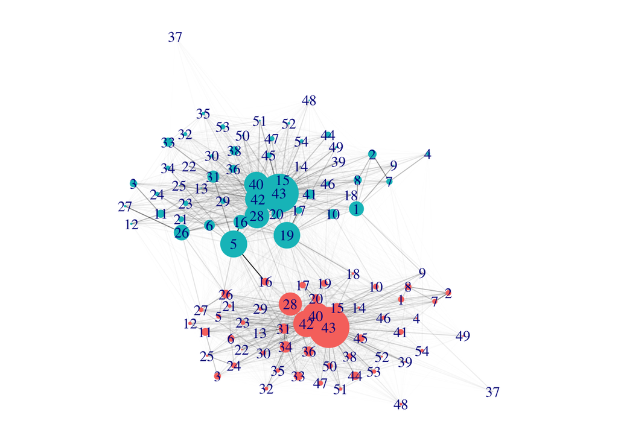

```r
library(igraph)
library(qgraph)
go <- rowSums(initial$A.matrix)
g <- graph_from_adjacency_matrix(as.matrix(initial$A.matrix),
                                 mode = 'directed', weighted = TRUE,diag = F, add.colnames = T)

# Graph Visualization
l <- qgraph.layout.fruchtermanreingold(get.edgelist(g, names=FALSE), vcount=vcount(g))
V(g)$size <- 7.5 * go ^ 0.75
V(g)$frame.color <- NA
# V(g)$name <- apply(expand.grid(1 : unique(initial$K), initial$countries)[c(2,1)], 1, function(x) paste0(x, collapse = ""))
V(g)$name <- rep(1 : unique(initial$K), times = 2)
V(g)$color <- rep(scales :: hue_pal()(4)[c(1, 3)], each = unique(initial$K))
E(g)$color <- alpha('black', E(g)$weight / max(E(g)$weight))

par(mar = c(0,0,0,0))
plot(g, edge.arrow.size = 0)
```

```r
# title("MRIO (EU, red; RoW, emerald)")
```

Circular economy matrix $B$ is computed from the $A$ matrix using parameters `more.input` and `less.input` to obtain the new coefficients from the old ones.

# Calibration

## Load Targets

Target values are loaded in format long (`target.set`) and wide (`target.table.0`). Units are divided by 10,000 for convenience.

```r
#### LOAD TARGET VALUES ####
target.file <- paste0(directory, 'data/target_values.xlsx')
target.table.0 <- openxlsx :: read.xlsx(target.file, sheet = 'Target', rowNames = TRUE) / 10000
target.set <- data.frame(region = rep(c('Z1', 'Z2'), times = dim(target.table.0)[2]),
                         var.label = rep(c('c', 'id', 'g', 'rex', 'imp', NA, 'M_TOT_int', 'fd', 'va', 'go', 'gdef', NA, NA), each = 2),
                         value = unlist(target.table.0))
target.vars <- target.set$var.label[!is.na(target.set$var.label)]
target.set$var[!is.na(target.set$var.label)] <- paste0(target.set$region[!is.na(target.set$var.label)], '_', target.set$var[!is.na(target.set$var.label)])
target.set$type <- setNames(variable.table$type, variable.table$label)[target.set$var.label]
target.set$variable <- paste0(setNames(variable.table$name, variable.table$label)[target.set$var.label], '\n(', target.set$var.label, ')')
target.set$unit <- setNames(variable.table$unit, variable.table$label)[target.set$var.label]
target.set$name <- ifelse(target.set$unit == '',
                    paste0(setNames(variable.table$name, variable.table$label)[target.set$var.label], '\n(', target.set$var.label,')'),
                    paste0(setNames(variable.table$name, variable.table$label)[target.set$var.label], '\n(', target.set$var.label,', in ', target.set$unit, ')'))

head(target.set)
```

```
##    region var.label     value   var              type
## C1     Z1         c  626.3179  Z1_c        households
## C2     Z2         c 2370.7060  Z2_c        households
## I1     Z1        id  196.6151 Z1_id        investment
## I2     Z2        id  908.6721 Z2_id        investment
## G1     Z1         g  239.4593  Z1_g govt.central.bank
## G2     Z2         g  675.3284  Z2_g govt.central.bank
##                                  variable    unit
## C1            Total Real Consumption\n(c) 10B.EUR
## C2            Total Real Consumption\n(c) 10B.EUR
## I1 Real Investment in Fixed Capital\n(id) 10B.EUR
## I2 Real Investment in Fixed Capital\n(id) 10B.EUR
## G1               Government Spending\n(g) 10B.EUR
## G2               Government Spending\n(g) 10B.EUR
##                                                  name
## C1            Total Real Consumption\n(c, in 10B.EUR)
## C2            Total Real Consumption\n(c, in 10B.EUR)
## I1 Real Investment in Fixed Capital\n(id, in 10B.EUR)
## I2 Real Investment in Fixed Capital\n(id, in 10B.EUR)
## G1               Government Spending\n(g, in 10B.EUR)
## G2               Government Spending\n(g, in 10B.EUR)
```

```r
target.table.0
```

```
##             C        I        G         X         M    X.int    M.int       FD
## EU   626.3179 196.6151 239.4593 102.77593  66.35708 105.8546 123.1518 1098.811
## ROW 2370.7060 908.6721 675.3284  66.35708 102.77593 123.1518 105.8546 3918.288
##          GDP       GO GDEF DEBT.GDP  BS
## EU  1081.514 2153.602 0.25      0.8 100
## ROW 3935.585 8424.517 0.25      0.6 100
```

## Target Values

```r
target.set$target[!is.na(target.set$var)] <- baseline$simulation[target.set$var[!is.na(target.set$var)],
                                                                 baseline$initial$pars['nPeriods', 'value']]
target.set$ratio <- round(target.set$target / target.set$value, 2)

compute.target(baseline)
```

```
## $table
##                C1          C2          I1         I2         G1          G2
## value  626.317880 2370.705952 196.6150852 908.672096 239.459251 675.3283891
## target 639.442534 2490.186243 193.4427224 926.058386 240.000000 675.0000000
## ratio    1.020955    1.050399   0.9838651   1.019134   1.002258   0.9995137
##                X1         X2         M1         M2   X.int1   X.int2     M.int1
## value  102.775931 66.3570804 66.3570804 102.775931 105.8546 123.1518 123.151817
## target 103.050978 60.7293075 60.7293075 103.050978       NA       NA 125.474198
## ratio    1.002676  0.9151896  0.9151896   1.002676       NA       NA   1.018858
##            M.int2         FD1         FD2        GDP1        GDP2         GO1
## value  105.854567 1098.811066 3918.287587 1081.513816 3935.584836 2153.602494
## target 108.929424 1165.206927 4278.922959 1237.843213 4580.169886 2188.158529
## ratio    1.029048    1.060425    1.092039    1.144547    1.163784    1.016046
##                GO2       GDEF1      GDEF2 DEBT.GDP1 DEBT.GDP2 BS1 BS2
## value  8424.517003  0.25000000  0.2500000       0.8       0.6 100 100
## target 8687.182370 -0.02477849 -0.1872231        NA        NA  NA  NA
## ratio     1.031179 -0.09911397 -0.7488925        NA        NA  NA  NA
##
## $total.fit
## [1] 0.2173479
##
## $fitness
## [1] 0.2173479
```

# Visualization

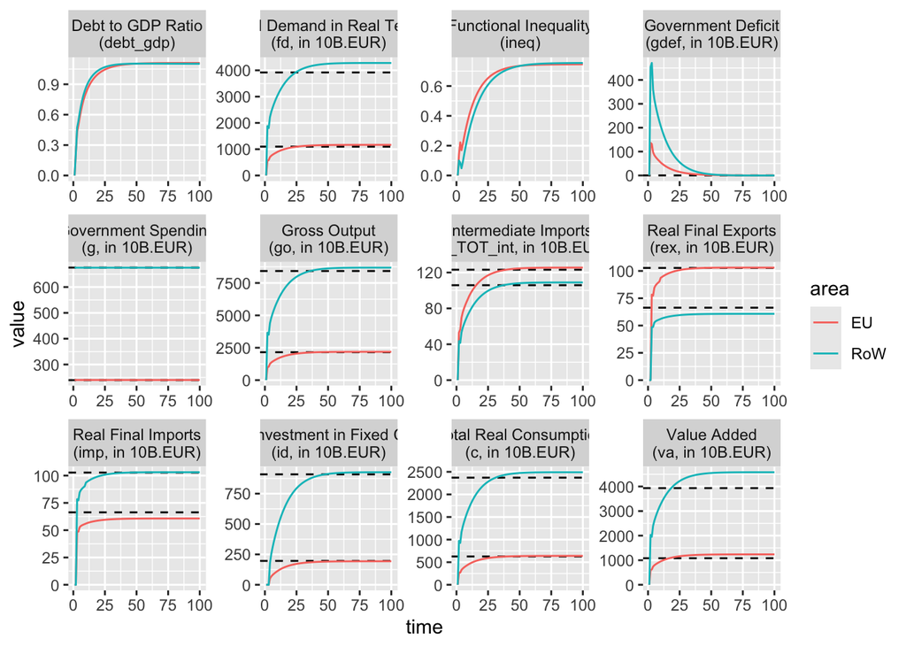

```r
plot.vars(baseline, c(target.vars, 'ineq', 'debt_gdp'))
```

# Shock Example

## Simple Visualization

This is a simple visualization of shock 1. Please note the new grammar to change initial values.

```r
selected <- c('n', 'c', 'ineq', 'va', 'cab', 'nf', 'gdef', 'tb', 'go')

initial$pars['shock', 'value'] <- 1 # shock 1
shock.1.54 <- run.new.model(initial, mvp.model)
```

```
## Time difference of 5.593559 mins
```

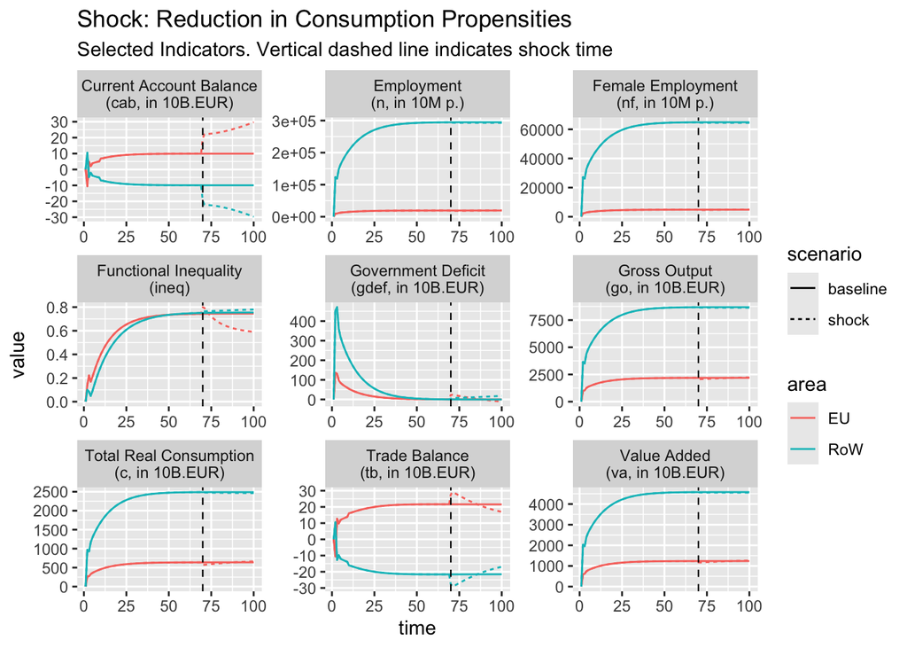

```r
shock.title <- paste0('Shock: Reduction in Consumption Propensities')

df <- shock.long.new(baseline, shock.1.54)

# Selected Vars to plot
p.selected.vars <- filter(df, variable %in% selected) %>%
    ggplot(aes(x = time, y = value, color = area, linetype = scenario)) + facet_wrap(~ name, scales = 'free') + geom_line() +
    geom_vline(xintercept = initial$pars['t.shock', 'value'], linetype = 'dashed', linewidth = .4) +
    labs(title = shock.title, subtitle = 'Selected Indicators. Vertical dashed line indicates shock time')

p.selected.vars
```

## Scaled Visualization

This is a scaled visualization of shock 1.

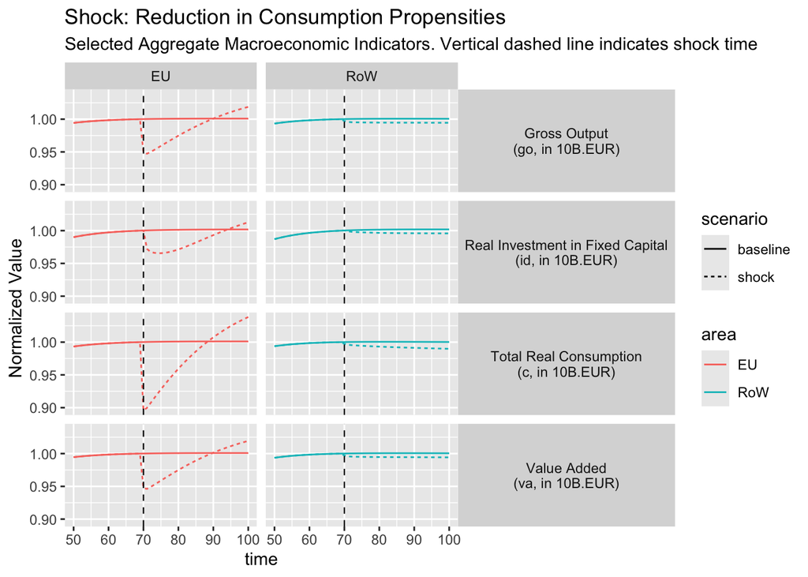

```r
# Variable Selection
macro.vars <- c('c', 'va', 'go','id')
external.vars <- c('cab', 'gdef', 'tb', 'nimp')
social.vars <- c('n', 'nf', 'ineq', 'pa')

# Time Period Selection
t.shock <- initial$pars['t.shock', 'value'] # shock time period
t0 <- 50 # initial time period for visualization
tf <- initial$pars['nPeriods', 'value'] # final time period for visualization

# df <- shock.long.new(baseline.54, shock.1.54) # already run above
df <- df %>% filter(time >= t0 & time <= tf)
df$ref.value <- rep(filter(df, time == (t.shock - 1)) %>% select(value), times = tf - t0 + 1) %>% unlist
df$norm.value <- df$value / df$ref.value

# Macro Vars
p.macro <- filter(df, variable %in% macro.vars) %>% ggplot(aes(x = time, y = norm.value, color = area, linetype = scenario)) + ylab('Normalized Value') +
  facet_grid(name ~ area) + geom_line() + theme(strip.text.y.right = element_text(angle = 0)) +
  geom_vline(xintercept = t.shock, linetype = 'dashed', linewidth = .4) +
  labs(title = shock.title, subtitle = 'Selected Aggregate Macroeconomic Indicators. Vertical dashed line indicates shock time') + coord_cartesian(xlim = c(t0, tf))

# Social Vars
p.social <- filter(df, variable %in% social.vars) %>% ggplot(aes(x = time, y = norm.value, color = area, linetype = scenario)) + ylab('Normalized Value') +
  facet_grid(name ~ area) + geom_line() + theme(strip.text.y.right = element_text(angle = 0)) +
  geom_vline(xintercept = t.shock, linetype = 'dashed', linewidth = .4) +
  labs(title = shock.title, subtitle = 'Selected Aggregate Social Indicators. Vertical dashed line indicates shock time') + coord_cartesian(xlim = c(t0, tf))

# External Vars
p.external <- filter(df, variable %in% external.vars) %>% ggplot(aes(x = time, y = value, color = area, linetype = scenario)) + ylab('Value') +
  facet_grid(name ~ area, scales = 'free_y') + geom_line() + theme(strip.text.y.right = element_text(angle = 0)) +
  geom_vline(xintercept = t.shock, linetype = 'dashed', linewidth = .4) +
  labs(title = shock.title, subtitle = 'Balance of Payments and Government Balance Indicators. Vertical dashed line indicates shock time') + coord_cartesian(xlim = c(t0, tf))

# Print Plots
print(p.macro)
```

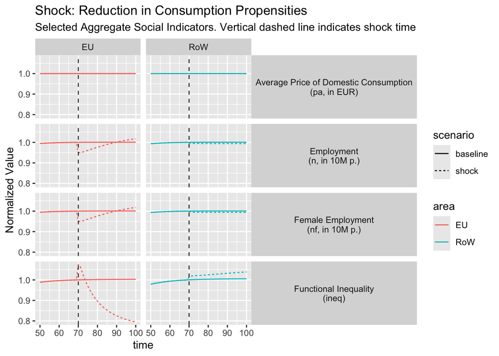

```r
print(p.social)
```

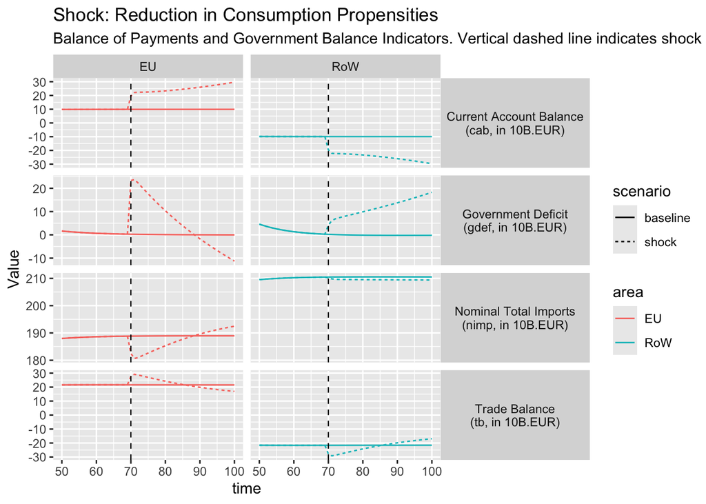

```r
print(p.external)
```